# Shark Attack Human Activity Data

Sam Fisher

April 27, 2016

## Preprocessing

#### Load the Data…

```r
## ---- Load the data
dat <- read_csv("Shark_Attack_Data_4-7-2016.csv",col_names=TRUE,n_max=5897) #5897=last good row
dat[24] <- NULL #remove null rows and repeated 'Case Number' rows
dat[23] <- NULL
dat[21] <- NULL
dat[20] <- NULL

# Rename the 'Case Number' column
colnames(dat)[1] <- "CaseNumber"
# Rename the 'Fatal (Y/N)' column
colnames(dat)[13] <- "Fatal"
```

#### Clean the data…

1. Remove duplicate entries
2. Standardize the encoding of the Activity, Type, and Fatal columns to UTF-8
3. Standardize the character cases of Activity and Type columns to lower; Fatal to uppercase

```r
## ---- Clean the data

# 1. Remove duplicate entries
dat <- dat %>% filter(!duplicated(CaseNumber))

# 2. Standardize the encoding of the Activity, Type, and Fatal columns
dat <- dat %>%
  mutate(Activity=iconv(Activity,from="CP1252",to="UTF-8"),
         Type=iconv(Type,from="CP1252",to="UTF-8"),
         #Species=iconv(Species,from="CP1252",to="UTF-8"),
         Fatal=iconv(Fatal,from="CP1252",to="UTF-8"))

# standardize the character cases of Activity and Type columns to lower; Fatal to uppercase
dat <- dat %>%
  mutate(Activity=stri_trans_tolower(Activity),
         Type=stri_trans_tolower(Type),
         #Species=stri_trans_tolower(Species),
         Fatal=stri_trans_toupper(Fatal))
```

4. Remove `NA` and empty Activity entries (and create activity_dat data frame)

```r
activity_dat <- dat %>% select(CaseNumber,Activity,Type,Fatal) %>% filter(!is.na(Activity))
activity_dat <- activity_dat %>% filter(nchar(Activity)>2) # filter out null/empty activities
```

5. Remove punctuation from Activity entries

```r
# Remove punctuation
activity_dat <- activity_dat %>%
  mutate(Activity=str_trim(gsub("[\\.\\s\"'`\\?\\(\\),;:-]+"," ",Activity,perl=TRUE)),
         Activity=gsub("[\\s]+"," ",Activity,perl=TRUE),
         Activity=gsub("( \\/ )"," or ",Activity,perl=TRUE))
```

## Exploring the data

What is the distribution of word counts per Activity entry?

```r
activity_word_count <- activity_dat %>%
  mutate(num_words=
           # http://stackoverflow.com/questions/8920145/count-the-number-of-words-in-a-string-in-r
           sapply(gregexpr("[[:alpha:]]+", Activity), function(x) sum(x > 0))
         ) %>%
  select(num_words,Activity)

summary(activity_word_count$num_words)
```

```
##    Min. 1st Qu.  Median    Mean 3rd Qu.    Max.
##   1.000   1.000   1.000   2.575   3.000  46.000
```

The average is 2.5746547 words. The median is 1 word and the max is 46.

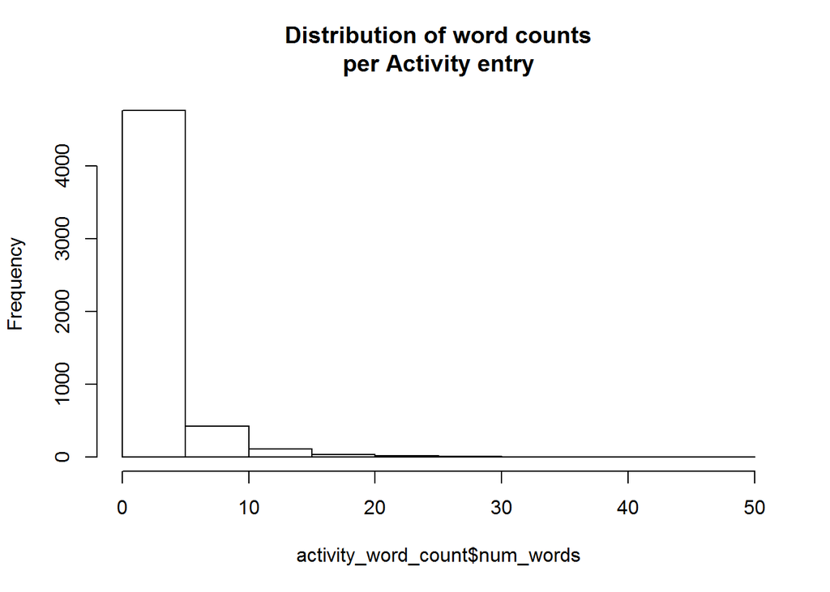

```r
hist(activity_word_count$num_words, main="Distribution of word counts\nper Activity entry")
```

(SCRAP THIS CODE CHUNK)

```r
activity_word_count %>% filter(num_words>3) %>% nrow()
activity_word_count %>% filter(num_words==3) %>% nrow()
activity_word_count %>% filter(num_words==2) %>% nrow()
activity_word_count %>% filter(num_words==1) %>% nrow()

qqnorm(activity_word_count$num_words,main="Distribution of Word Counts\nper Activity entry")
```

We know what the counts per activity are, but what does the full vocabulary of words describing Activity look like?

#### Composition of words in Activity entries…

1. Get all the words

```r
all_words_text <- paste(unlist(activity_dat$Activity),collapse=" ")
#all_words_text <- gsub(" NA "," ",all_verbs_text)
all_words <- str_split(all_words_text," ")[[1L]]
```

1950 words are used to describe all of the Activity entries. Here are the top 20 and their frequencies.

2. Inspect the frequency of words

```r
all_words_freqs <- as.data.frame(table(w=all_words)) %>% arrange(desc(Freq))
all_words_freqs %>% filter(Freq>20) %>% head(20)
```

```
##               w Freq
## 1      swimming 1047
## 2       surfing 1001
## 3       fishing  701
## 4        diving  527
## 5  spearfishing  407
## 6           the  352
## 7            in  244
## 8             a  234
## 9            on  207
## 10          for  205
## 11        water  201
## 12        shark  184
## 13           to  180
## 14      bathing  179
## 15            &  177
## 16       wading  167
## 17           of  162
## 18         from  158
## 19     standing  145
## 20         boat  139
```

And here is a visualization of them:

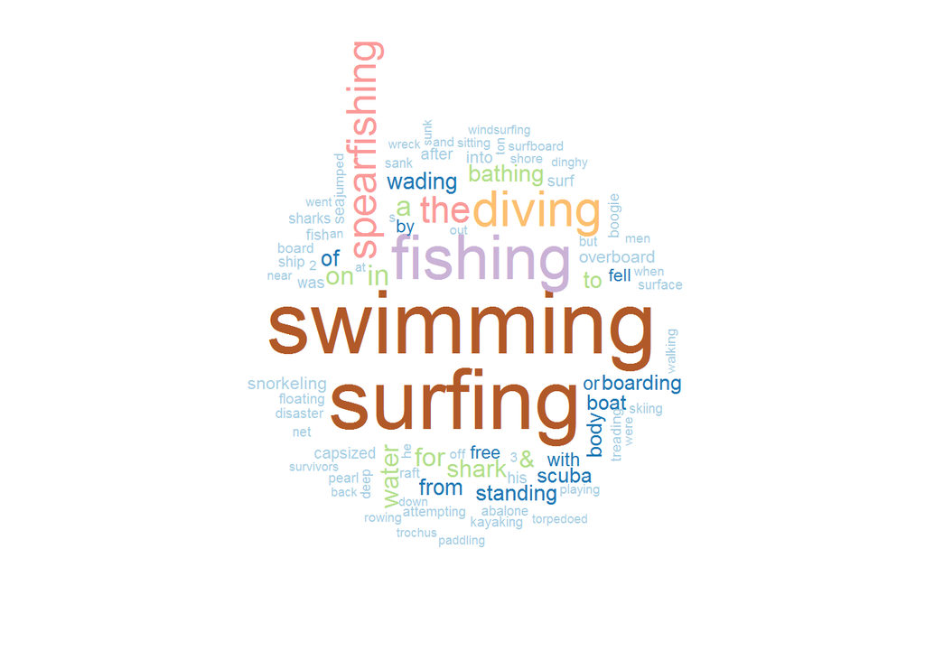

```r
wordcloud(all_words_freqs$w,all_words_freqs$Freq,
          min.freq = 20,#c(4,1),
          random.order=FALSE,
          color=brewer.pal(12,"Paired"))
```

```r
          #colors=brewer.pal(16, "Dark2"))
```

Only 8 of the top 20 most frequent words appear to describe an activity. A lot of cleaning and standardization is needed before we can isolate the content words, or words that characterize an activity. Bear in mind, the purpose of these content words is to represent a set of values (i.e. categories, classes), a feature, in the larger model of shark attack fatality prediction. Leveraging ‘Fatal’ especially, but also the Type variable will help make the Activity categories more applicable as a distribution.

There are many ways to go about isolating standardized content words into feature classes. Too many classes and the model will fail; too few may not be effective enough. But be careful of overfitting. First, some questions about the data…

The activity classes need to be English-interpretable. Each one must be labeled with some text that can be mapped to its more normal form. This is different than Principle Component Analysis. The class label needs to contain much of the same form as the words that together give it its distributional usage characteristics.

After examining the list of words and their frequencies, several require further standardization.

3. Perform compounding (or decompounding) and synonyming on high frequency activity words.

```r
# Normalize certain activity names...
activity_dat <- activity_dat %>%
         mutate(
        # This mutation creates LESS activity variation (more factors) by separating
        Activity=gsub("([a-z])(div|ski|surf|board)(ing)","\\1 \\2\\3",Activity,perl=TRUE),

         # This mutation creates GREATER activity variation of activity by concatenating
        #Activity=gsub("([a-z]) (div|ski|surf|board|fish)(ing)","\\1\\2\\3",Activity,perl=TRUE),

        #bodyboarding and bodysurfing are the same activity
        Activity=gsub("(body|skin)[\\s]?(surf|board)","bodyboard",Activity,perl=TRUE),

        #spearfishing and spear fishing -- spearfishing is similar to freediving except that it carries the
        # intention of blood being spilt in the water. And blood attracks sharks.
        Activity=gsub("(spear)[\\s-](fish)","\\1fish",Activity,perl=TRUE),

        #treat windsurfing, kitesurfing, and sailboarding the same. kneeboarding??
        Activity=gsub("(wind|kite|sail|knee)[\\s-](board|surf)","windboard",Activity,perl=TRUE),

        #paddle boarding
        Activity=gsub("(paddle)[\\s-](board)","paddleboard",Activity,perl=TRUE),

        #treat kayaking, canoeing the same
        Activity=gsub("(kayak|canoe)","kayak",Activity,perl=TRUE),

        #boogie/skim boarding
        Activity=gsub("(boogie|skim)[\\s-](board)","boogieboard",Activity,perl=TRUE),

        #overboard
        Activity=gsub("(over|ove)[\\s-](board)","overboard",Activity,perl=TRUE),

        #free diving
        Activity=gsub("(hookah|free)[\\s](div)","\\1div",Activity,perl=TRUE),

        #scuba diving
        Activity=gsub("(scuba)[\\s-](div)","\\1div",Activity,perl=TRUE)
        )
```

Removing stop words To remove stop words, we’ll rely on part-of-speech tags.

Deriving Activity Factors from Free-Form Text Descriptions Clues in the morphological frequencies position of word in text multiword activity descriptions

4. Tag entries for parts-of-speech

```r
require(NLP)
library(openNLP)
library(openNLPmodels.en)

sent_token_annotator <- openNLP::Maxent_Sent_Token_Annotator(language = "en")
word_token_annotator <- openNLP::Maxent_Word_Token_Annotator()
pos_tag_annotator <- openNLP::Maxent_POS_Tag_Annotator(probs = FALSE)

pos_tagger <- function(x){
  ## from http://www.martinschweinberger.de/blog/part-of-speech-tagging-with-r/

  y1 <- NLP::annotate(x, list(sent_token_annotator, word_token_annotator))
  y2 <- NLP::annotate(x, pos_tag_annotator, y1)
#  y3 <- annotate(x, Maxent_POS_Tag_Annotator(probs = TRUE), y1)
  y2w <- subset(y2, type == "word")
  tags <- sapply(y2w$features, '[[', "POS")
  r1 <- sprintf("%s/%s", x[y2w], tags)
  r2 <- paste(r1, collapse = " ")
  r2 <- gsub("\\/","_",r2)
  return(r2)  }

# Extract/format all activities as String class so NLP can be used.
acts_all <-  lapply(activity_dat$Activity,function(x){ x <- as.String(x)})
# Tag all activities for parts-of-speech (POS)
acts_tagged <- lapply(acts_all,FUN=pos_tagger)
rm(acts_all) # remove acts_all to save space
# Replace POS tag delimiter from '/' to '_'
#acts_tagged <- lapply(acts_tagged,function(x){
#  return(gsub("([\\/]{1})([A-Z])","_\\2",x))
#  #return(gsub("[_]{2}RB","\\/__RB",x))
#})

activity_dat2 <- cbind(activity_dat,tagged=as.character(acts_tagged))
activity_dat2 %>% select(Activity,tagged) %>% head(5) %>% kable
```

| Activity | tagged |
| --- | --- |
| diving for beche de mer | diving_NN for_IN beche_PRP de_IN mer_NN |
| fishing | fishing_NN |
| swimming | swimming_VBG |
| windboarding | windboarding_VBG |
| spearfishing | spearfishing_VBG |

Set up some functions to handle upcoming processes including text extraction, word-stemming, irregular verb lemmatization, and removal of non-activity verbs (e.g. auxiliaries, modals, etc.) and nouns.

```r
extractAllFlat <- function(x,ptn){
  # call from within lapply when using mutate
  extracts <- str_extract_all(x,ptn)
  return(paste(unlist(extracts),collapse=" "))
}

require(SnowballC)
stemGivenWords <- function(w){
  # call from within lapply when using mutate
  t <- unlist(str_split(w," "))
  stems <- wordStem(t,language = "english")
  return(paste(unlist(stems),collapse=" "))
}

replaceIrregVerbForms <- function(w){
  w <- gsub("(^|[\\s])(s)([\\s]|$)"," ",w, perl=TRUE)
  w <- gsub("(^|[\\s])(fell)([\\s]|$)"," fall ",w, perl=TRUE)
  w <- gsub("(^|[\\s])(sank|sunk)([\\s]|$)"," sink ",w, perl=TRUE)
  w <- gsub("(^|[\\s])(swam|swum)($|[\\s])"," swim ",w, perl=TRUE)
  w <- gsub("(^|[\\s])(stood)($|[\\s])"," stand ",w, perl=TRUE)
  w <- gsub("(^|[\\s])(saw)($|[\\s])"," see ",w, perl=TRUE)
  w <- str_trim(w)

  if(nchar(w)<2){
    return(NA)
  }
  return(w)
}

removeModalVerbs <- function(w){
  w <- gsub("(^|[\\s])(attempt|torpedo|founder|use|hold|cling|attack|drown|go|going|gone|went|was|is|been|being|be|becam|began|believ|see|were|do|doing|did|does|had|have|swamp|will)([\\s]|$)"," ",w, perl=TRUE)
  return(w)
}
```

6. Limit activity words to active verbs, nouns that end in “-ing”, and the word “overboard”.

```r
# limit activity words to active verbs, "nouns" that end in -ing, and "overboard".
verbs_dat <- activity_dat2 %>%
  mutate(verbs=tagged,
         verbs=gsub("([a-z]+ing)(_NN)","\\1_VBG",verbs,perl=TRUE),
         verbs=sapply(verbs,FUN=extractAllFlat,ptn="\\b([a-z]+_VB[DGZN]?|overboard_RB)\\b"),
         verbs=gsub("(_[A-Z]+[\\s]?)"," ",verbs,perl=TRUE) # REMOVE POS TAGS
         )

#fatal_words <- verbs_dat %>% filter(Fatal=="Y",nchar(verbs)>2) %>% select(verbs) %>% table(w=verbs)

#p <- cbind(r=seq(1,nrow(all_verb_freqs)),all_verb_freqs) %>% filter(Freq>freq_cutoff) %>% ggplot(aes(r,Freq, label = v)) +   ylab("frequency of mention") + xlab("rank") + ggtitle("Shark Attack-related Activities")
#p + scale_y_log10() + scale_x_continuous() + geom_point(size=2,color="red") + geom_text_repel(cex=4.5)

verbs_dat <- verbs_dat %>%
  mutate(verbs=sapply(verbs,FUN=stemGivenWords),
         verbs=sapply(verbs,FUN=replaceIrregVerbForms),
         verbs=sapply(verbs,FUN=removeModalVerbs),
         verbs=ifelse(nchar(verbs)<2,NA,verbs),
         Fatal=ifelse(Fatal=="UNKNOWN",NA,ifelse(Fatal=="F","Y",Fatal))

         ) %>% select(verbs,Type,Fatal)

#write.csv(verbs_dat$verbs,"active_verbs.csv",row.names = FALSE, quote = FALSE)
```

7. Inspect the remaining activity words…

```r
all_verbs_text <- paste(unlist(verbs_dat$verbs),collapse=" ")
all_verbs_text <- gsub(" NA "," ",all_verbs_text)
all_verbs <- str_split(all_verbs_text," ")[[1L]]

all_verb_freqs <- as.data.frame(table(v=all_verbs)) %>% arrange(desc(Freq))
all_verb_freqs %>% head(20) %>% kable
```

| v | Freq |
| --- | --- |
| swim | 1057 |
| surf | 934 |
| fish | 699 |
| spearfish | 410 |
| dive | 322 |
| bath | 179 |
| wade | 167 |
| stand | 151 |
|  | 136 |
| bodyboard | 125 |
| scubadiv | 117 |
| freediv | 100 |
| fall | 93 |
| overboard | 87 |
| snorkel | 85 |
| sink | 76 |
| capsiz | 70 |
| kayak | 50 |
| boogieboard | 49 |
| tread | 49 |

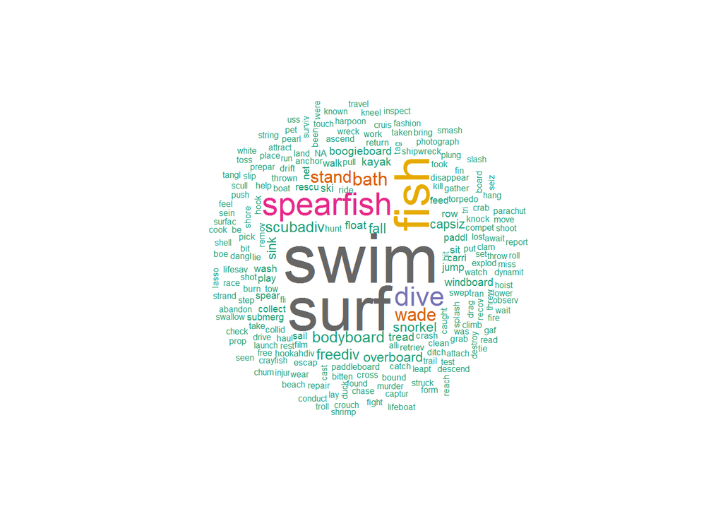

```r
wordcloud(all_verb_freqs$v,all_verb_freqs$Freq,
          min.freq = 2,#c(4,1),
          random.order=FALSE,
          colors=brewer.pal(8, "Dark2"))
```

```r
all_verb_freqs %>% tail(20) %>% kable
```

|  | v | Freq |
| --- | --- | --- |
| 377 | swimmng | 1 |
| 378 | teas | 1 |
| 379 | tend | 1 |
| 380 | tether | 1 |
| 381 | thrash | 1 |
| 382 | torn | 1 |
| 383 | transfer | 1 |
| 384 | trawl | 1 |
| 385 | turn | 1 |
| 386 | untangl | 1 |
| 387 | upset | 1 |
| 388 | urin | 1 |
| 389 | vanish | 1 |
| 390 | warn | 1 |
| 391 | wedg | 1 |
| 392 | went | 1 |
| 393 | whale | 1 |
| 394 | woke | 1 |
| 395 | wrangl | 1 |
| 396 | yacht | 1 |

8. Set a lower word frequency cut-off threshold

```r
freq_cutoff <- 11
```

9. Plot the words whose frequencies are higher than the cut-off threshold

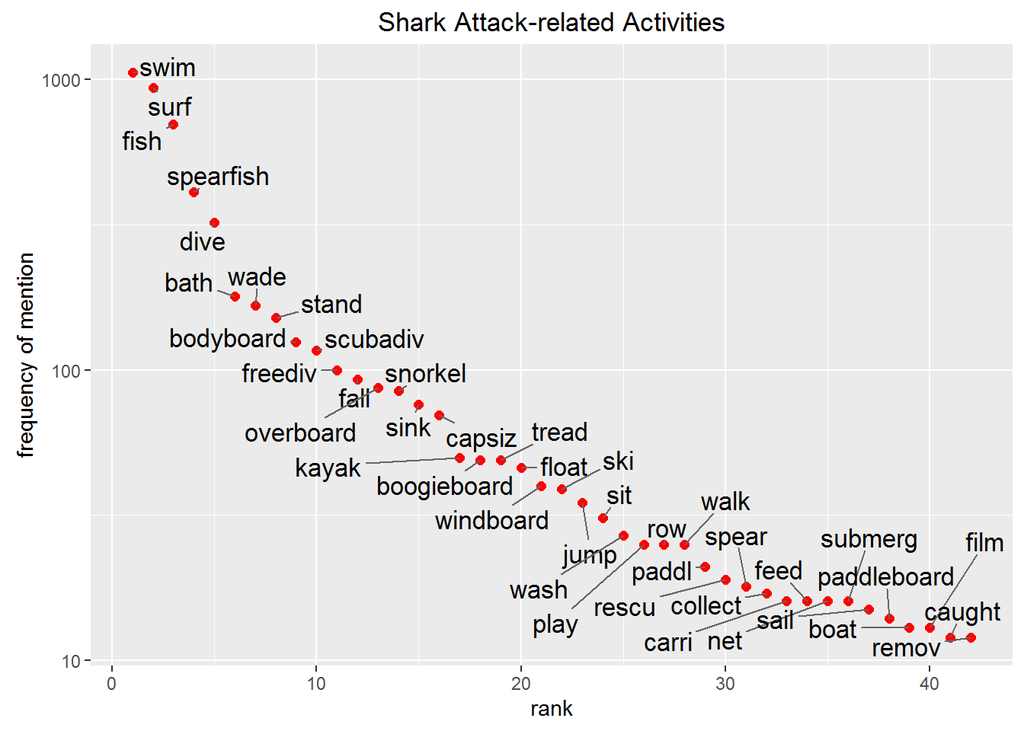

```r
all_verb_freqs$v <- as.character(all_verb_freqs$v)
all_verb_freqs <- all_verb_freqs %>% filter(!is.na(v),nchar(v)>2)
# This is repeated below. need to do only once...
p <- cbind(r=seq(1,nrow(all_verb_freqs)),all_verb_freqs) %>% filter(Freq>freq_cutoff) %>% ggplot(aes(r,Freq, label = v)) +
  ylab("frequency of mention") + xlab("rank") + ggtitle("Shark Attack-related Activities")
p + scale_y_log10() + scale_x_continuous() + geom_point(size=2,color="red") +
  geom_text_repel(cex=4.5)
```

## Activity Label Assignment (Part 1)

So we know the most frequent activity-characterizing words. Let’s now try to treat these words as factors for the Activity variable of our prediction model.

```r
# What are the fifty most common terms in verbs?
# make a table of all single-word activities and their frequencies.
# Use this table to choose the highest scoring single-word activities in entries containing
# multi-word activities


vFreqs <- all_verb_freqs %>%
  subset(Freq>freq_cutoff) %>% data.frame() %>%
  arrange(desc(Freq))
vFreqs %>% kable(caption=paste(freq_cutoff," Most Frequent Activity Words",sep=""))
```

| v | Freq |
| --- | --- |
| swim | 1057 |
| surf | 934 |
| fish | 699 |
| spearfish | 410 |
| dive | 322 |
| bath | 179 |
| wade | 167 |
| stand | 151 |
| bodyboard | 125 |
| scubadiv | 117 |
| freediv | 100 |
| fall | 93 |
| overboard | 87 |
| snorkel | 85 |
| sink | 76 |
| capsiz | 70 |
| kayak | 50 |
| boogieboard | 49 |
| tread | 49 |
| float | 46 |
| windboard | 40 |
| ski | 39 |
| jump | 35 |
| sit | 31 |
| wash | 27 |
| play | 25 |
| row | 25 |
| walk | 25 |
| paddl | 21 |
| rescu | 19 |
| spear | 18 |
| collect | 17 |
| carri | 16 |
| feed | 16 |
| net | 16 |
| submerg | 16 |
| sail | 15 |
| paddleboard | 14 |
| boat | 13 |
| film | 13 |
| caught | 12 |
| remov | 12 |

```r
assign_label <- function(x){

  if(nchar(x)<1){
    return(NA)
  }
    toks <- str_split(x," ")[[1]]
    toks <- toks[toks%in%vFreqs$v]
    #toks <- vFreqs %>% filter(v%in%toks) %>% select(v)[[1]]
  if(length(toks)<1){
    return(NA)
  }

    if(length(toks)>1 & c("swim")%in%toks){
      #remove swim if there are other activities mentioned
      toks <- !toks%in%c("swim")
    }

    tok <- vFreqs %>% filter(v%in%toks) %>% arrange(desc(Freq)) #arrange(desc(Freq))
    #tok <- tok[which(max(tok$Freq))]
    return(paste(tok[1,1],sep=""))
}

activities_labeled <- verbs_dat %>%
  mutate(activity_cat=sapply(verbs,FUN=assign_label),
         activity_cat=ifelse(activity_cat=="NA",NA,activity_cat)) %>%
         #,activity_cat=as.factor(activity_cat)) %>%
  select(activity_cat,Type,Fatal)

activities_labeled <- cbind(activities_labeled,CaseNumber=activity_dat$CaseNumber)

# What % of incidents currently not covered by one of the N categories.
pct_attacks_not_labeled <- round(sum(is.na(activities_labeled$activity_cat))/nrow(activities_labeled),2)*100
pct_attacks_not_labeled
```

```
## [1] 10
```

```r
n_distinct(activities_labeled$activity_cat)
```

```
## [1] 43
```

```r
## Write labeled activities to csv file
#activities_labeled %>% select(CaseNumber,activity_cat) %>%
#  write.csv("activities_labeled.csv", row.names = FALSE, quote = FALSE)
```

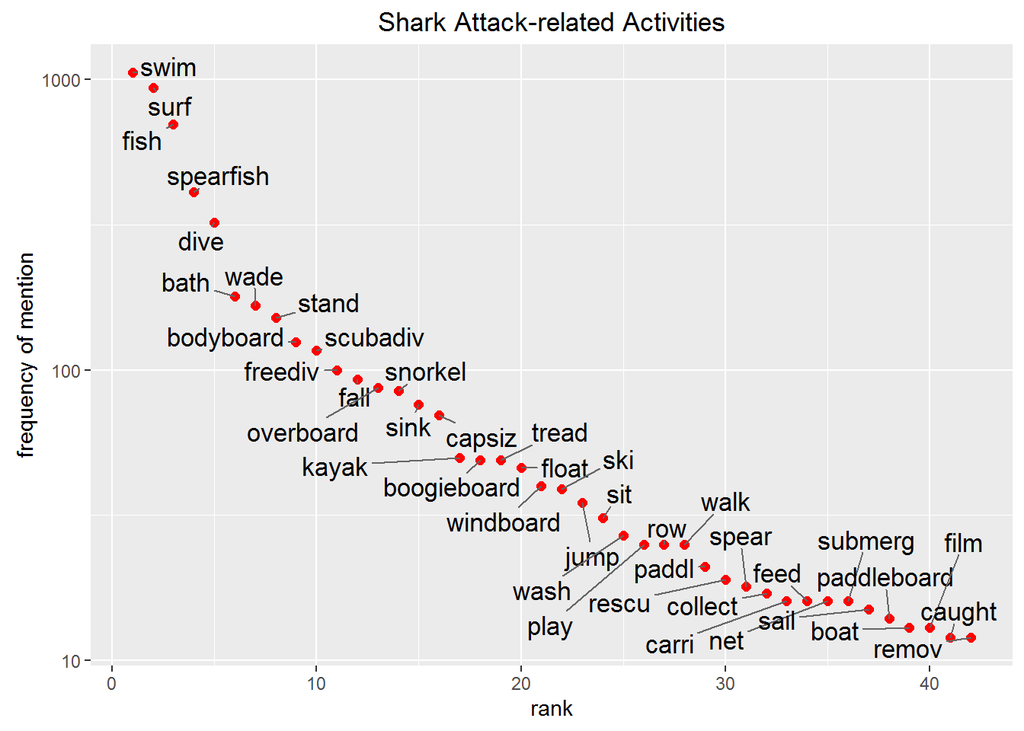

```r
#verbs_dat %>% group_by(verbs,Type) %>%
#  summarize(f=n(),fatalities=sum(as.numeric(Fatal=="Y"))) %>%
#  arrange(desc(f),verbs,Type) %>% View() #%>% ungroup #%>%
  #select(verbs,Type,freq,fatalities)

#ggplot(verbs,data=verbs_dat,facets=Type)

#all_verbs_text <- paste(unlist(verbs_nouns$verbs),collapse=" ")
#all_verbs <- str_split(all_verbs_text," ")[[1L]]

#zipfR::zipfR.begin.plot()

#vFreqs <- data.frame(v=all_verbs) %>% filter(!is.na(v) & v!="NA") %>% group_by(v) %>% #summarize(f=n()) %>% arrange(desc(f)) %>%
#  cbind(r=seq(1,nrow(.)))

#vFreqs %>% qplot(Freq)

#p <- subset(vFreqs,f>20,select = c(r,f,v)) %>% ggplot(aes(r, f, label = v))
p <- cbind(r=seq(1,nrow(vFreqs)),vFreqs) %>% ggplot(aes(r,Freq, label = v)) + ylab("frequency of mention") + xlab("rank") + ggtitle("Shark Attack-related Activities")
p + scale_y_log10() + scale_x_continuous() + geom_point(size=2,color="red") +
  geom_text_repel(cex=4.5)
```

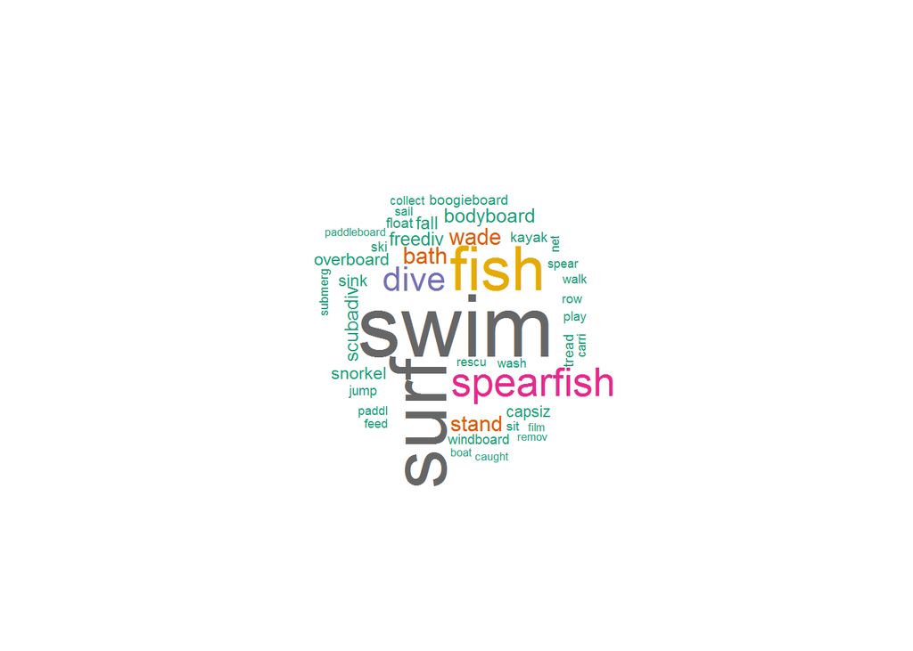

```r
                  #,nudge_x = 0.5
                  #,nudge_y = 0.5)

wordcloud(vFreqs$v,vFreqs$Freq,
          min.freq = 8,#c(4,1),
          random.order=FALSE,
          colors=brewer.pal(8, "Dark2"))
```

## Exploring activities and shark attack fatalities…

```r
# Activities where fatality outcome is unknown
activity_dat %>% filter(is.na(activity_dat$Fatal)) %>% kable(caption="Fatality Outcome Unknown")
```

Fatality Outcome Unknown

| CaseNumber | Activity | Type | Fatal |
| --- | --- | --- | --- |
| 2015.11.01.a | fishing | unprovoked | NA |
| 2006.08.20.b | sea disaster | sea disaster | NA |
| 2000.03.03.R | kayaking | invalid | NA |
| 1989.07.27 | scubadiving | invalid | NA |
| 1967.09.13 | scubadiving | provoked | NA |
| 1964.09.27 | spearfishing | invalid | NA |
| 1958.12.28 | fishing | boating | NA |
| 1954.07.27 | fishing trawler flavio gioia | boating | NA |
| 1938.00.00.e.R | sponge diving | unprovoked | NA |
| 1901.07.17 | swimming | invalid | NA |
| 1899.09.11.R | swimming | unprovoked | NA |
| 1892.06.24 | fishing boat | invalid | NA |
| 1872.08.07.R | fishing | invalid | NA |

```r
# Number of Activity entries where fatality outcome is known
activity_dat %>% filter(!is.na(activity_dat$Fatal)) %>% nrow() #kable(caption="Fatality Outcome Known")
```

```
## [1] 5345
```

```r
#library(tidyr)

# Unique activity counts where fatality outcome is known
#attack_by_activity <- activity_dat %>% filter(!is.na(activity_dat$Fatal)) %>%
#select(activity_cat,Fatal)
n_distinct(verbs_dat$verbs)
```

```
## [1] 683
```

```r
attack_by_activity <- verbs_dat %>% filter(!is.na(Fatal),!is.na(verbs)) %>%
  group_by(verbs) %>%
  summarize(freq=n(),fatalities=sum(as.numeric(Fatal=="Y")),pct_fatal=round(fatalities/freq*100,2)) %>%
  arrange(desc(freq))
## Unique activity counts where fatality outcome is known
attack_by_activity %>% head(10)
```

```
## Source: local data frame [10 x 4]
##
##        verbs  freq fatalities pct_fatal
##        (chr) (int)      (dbl)     (dbl)
## 1       swim   914        383     41.90
## 2       surf   879         51      5.80
## 3       fish   566         68     12.01
## 4  spearfish   326         52     15.95
## 5       dive   267         78     29.21
## 6       bath   167         80     47.90
## 7       wade   141         14      9.93
## 8  bodyboard   112         22     19.64
## 9      stand   111         19     17.12
## 10  scubadiv    92         31     33.70
```

Plot attack-by-activity by proportion that are fatal…

```r
sum(attack_by_activity$freq[attack_by_activity$freq>1])
```

```
## [1] 4667
```

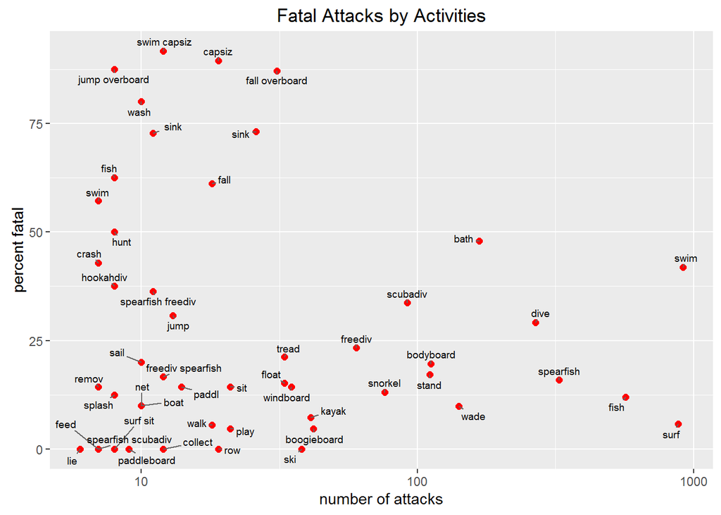

```r
#attack_by_activity %>% filter(freq>10) %>% select(freq) %>%
#  mutate(total_freqs=sum(freq)) %>% print(total_freqs)

#p <- subset(vFreqs,f>20,select = c(r,f,v)) %>% ggplot(aes(r, f, label = v))
p <- attack_by_activity %>% filter(freq>5) %>% ggplot(aes(freq,pct_fatal, label = verbs)) + ylab("percent fatal") + xlab("number of attacks") + ggtitle("Fatal Attacks by Activities")
p + geom_point(size=2,color="red") + scale_x_log10() + #xlim() #lims(x = c(15, 900), y = c(1, 100)) +
  geom_text_repel(cex=2.5)
```

How do these look when looking at their association to fatal shark attacks?

```r
# Unique activity counts where fatality outcome is known
#attack_by_activity <- activity_dat %>% filter(!is.na(activity_dat$Fatal)) %>%
#select(activity_cat,Fatal)

attack_by_activity <- activities_labeled %>% filter(!is.na(Fatal),!is.na(activity_cat)) %>%
  group_by(activity_cat) %>%
  summarize(freq=n(),fatalities=sum(as.numeric(Fatal=="Y")),pct_fatal=round(fatalities/freq*100,2)) %>%
  arrange(desc(freq))
## Unique activity counts where fatality outcome is known
attack_by_activity %>% head(20)
```

```
## Source: local data frame [20 x 4]
##
##    activity_cat  freq fatalities pct_fatal
##           (chr) (int)      (dbl)     (dbl)
## 1          swim   962        408     42.41
## 2          surf   920         52      5.65
## 3          fish   681        115     16.89
## 4     spearfish   401         66     16.46
## 5          dive   302         91     30.13
## 6          bath   176         84     47.73
## 7          wade   152         18     11.84
## 8         stand   133         23     17.29
## 9     bodyboard   117         23     19.66
## 10     scubadiv   103         31     30.10
## 11      snorkel    79         10     12.66
## 12         fall    71         51     71.83
## 13      freediv    70         15     21.43
## 14         sink    61         45     73.77
## 15  boogieboard    43          2      4.65
## 16        kayak    42          3      7.14
## 17          ski    38          0      0.00
## 18    windboard    38          5     13.16
## 19        float    36          6     16.67
## 20        tread    36         10     27.78
```

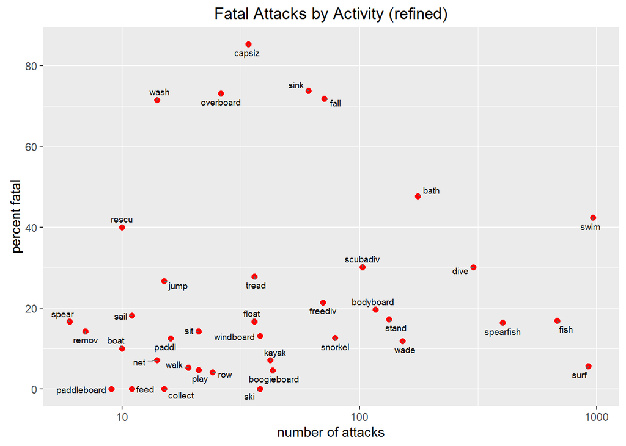

```r
p <- attack_by_activity %>% filter(freq>5) %>% ggplot(aes(freq,pct_fatal, label = activity_cat)) + ylab("percent fatal") + xlab("number of attacks") + ggtitle("Fatal Attacks by Activity (refined)")
p + geom_point(size=2,color="red") + scale_x_log10() + #xlim() #lims(x = c(15, 900), y = c(1, 100)) +
  geom_text_repel(cex=2.5)
```

#### Interpreting ‘swim’

As anyone should assume, swimming is involved when a shark attack occurs. It is a given, and the word we give to that activity characterizes being more or less deep in the water – where a shark might attack. In the above plot, notice that `swim` is the most reported activity involving shark attacks, and nearly 40% fatal – or half of the maximum of fatal attacks. This provides a good point of reference relative to the clusters or groupings of other activities involved in shark attacks.

More…

#### Overboard

Let’s look at language around the word ‘fall’…

```r
activity_dat2 %>% filter(grepl("(fall|fell)",tagged)) %>% select(tagged) %>% head(20)
```

```
##                                                                                                                                           tagged
## 1                                                                                                 swimming_VBG after_IN falling_VBG overboard_RB
## 2                                                                                                               fell_VBD into_IN the_DT water_NN
## 3                                                                 surfing_NN fell_VBD off_RP surfboard_RB &_CC stepped_VBD on_IN the_DT shark_NN
## 4                                                                                                              fell_VBD off_IN banana_NN boat_NN
## 5                                                                                                              fell_VBD onto_IN dead_JJ shark_NN
## 6                                                                                                         fell_VBD off_RP aircraft_NN carrier_NN
## 7                                                                                 swimming_VBG after_IN falling_VBG off_RP towed_DT kneeboard_NN
## 8                                                  fell_VBD from_IN cliff_NN while_IN fishing_NN &_CC disappeared_VBD in_IN strong_JJ current_JJ
## 9                                                                                            fell_VBD off_IN surfboard_NN 20_CD from_IN shore_NN
## 10                                               fell_VBD overboard_RB from_IN the_DT taiwanese_JJ fishing_NN trawler_NN lien_NN cheng_NN feu_NN
## 11                                                                                    fishing_NN fell_VBD from_IN rocks_NNS &_CC disappeared_VBN
## 12                                                                           sailing_NN on_IN catamaran_NN &_CC fell_VBD into_IN the_DT water_NN
## 13                                                   windboarding_VBG fell_VBD into_IN water_NN 100_CD yards_NNS outside_IN the_DT breakwater_NN
## 14                                                                                                       surfing_NN fell_VBD off_RP surfboard_NN
## 15                  overcome_VBN by_IN co_NN fumes_NNS fell_VBD overboard_RB from_IN 36_CD fishing_NN cruiser_NN &_CC prop_VB slashed_VBD arm_NN
## 16                                                                           fishing_NN slipped_VBD on_IN rocks_NNS &_CC fell_VBD into_IN sea_NN
## 17 survived_VBD us_PRP naval_JJ aircraft_NN crash_NN climbing_VBG onboard_IN rescue_NN vessel_NN when_WRB he_PRP fell_VBD back_RB into_IN sea_NN
## 18                                                         fishing_NN speared_VBD shark_NN upset_JJ kayak_NN &_CC man_NN fell_VBD in_IN water_NN
## 19                                                                               checking_VBG fish_NN traps_NNS fell_VBD into_IN the_DT water_NN
## 20                                                                                              fell_VBD overboard_RB prop_VB slashed_VBN arm_NN
```

```r
# remove all determiners (DT)
activity_dat2 %>% mutate(tagged=gsub("\\b[a-z]+_DT\\b"," ",tagged)) %>%
  filter(grepl("(fall|fell)",tagged)) %>%
  mutate(fall=str_extract(tagged,"(fall|fell|falling)_[A-Z]{2,3}([\\s][a-z]+_[A-Z]{2,3}){1,3}")) %>%
  select(fall,Type,Fatal) %>% head(30)
```

```
##                                         fall       Type Fatal
## 1                   falling_VBG overboard_RB    invalid     N
## 2                           fell_VBD into_IN unprovoked     N
## 3               fell_VBD off_RP surfboard_RB   provoked     N
## 4          fell_VBD off_IN banana_NN boat_NN unprovoked     N
## 5          fell_VBD onto_IN dead_JJ shark_NN   provoked     N
## 6     fell_VBD off_RP aircraft_NN carrier_NN unprovoked     N
## 7                         falling_VBG off_RP unprovoked     N
## 8         fell_VBD from_IN cliff_NN while_IN    invalid     Y
## 9               fell_VBD off_IN surfboard_NN unprovoked     N
## 10             fell_VBD overboard_RB from_IN    invalid     Y
## 11                fell_VBD from_IN rocks_NNS unprovoked     Y
## 12                          fell_VBD into_IN unprovoked     Y
## 13                 fell_VBD into_IN water_NN unprovoked     N
## 14              fell_VBD off_RP surfboard_NN unprovoked     N
```

[output cut: 16 more lines]

```r
vFreqs <- as.data.frame(table(v=all_verbs)) %>% mutate(v=gsub("_[A-Z]+","",v)) %>% filter(!is.na(v),v!="NA",
                                                                                          !grepl("(^|\\s)(was|went|bite|attempted|attempting|bitten|bites|were|had|saw|been|being|believed|s)(\\s|$)",v)) %>%
  arrange(desc(Freq))

vFreqs

line_plot(x=vFreqs$v,vFreqs$Freq,type="p",min=20)

cbind(x=seq(1,nrow(vFreqs)),vFreqs) %>% as.data.frame() %>% plot(x=x,Freq,type="p",min=20)

cbind(x=seq(1,nrow(vFreqs)),vFreqs) %>% head(5)
ggplot(vFreqs,aes(x=nrow(),y=Freq)) %>% geom_line()

verbs_nouns %>% length(unique(verbs)) %>% n_distinct() #%>%
  summarize(freq=n(),fatalities=sum(Fatal=="Y")) %>% head(10)

#select(verbs) %>% lapply(function(x){ x <- paste(x,sep=" ")})

#parse_annotator <- openNLP::Parse_Annotator()
#chunk_annotator <- openNLP::Maxent_Chunk_Annotator()

#chunker <- function(x){
#  y1 <- NLP::annotate(x, list(sent_token_annotator, word_token_annotator,pos_tag_annotator))
#  y2 <- NLP::annotate(x, chunk_annotator, y1)
##  y3 <- annotate(x, Maxent_POS_Tag_Annotator(probs = TRUE), y1)
#  y2w <- subset(y2, type == "word")
#  tags <- sapply(y2w$features, '[[', "POS")
#  r1 <- sprintf("%s/%s", x[y2w], tags)
#  r2 <- paste(r1, collapse = " ")
#  return(r2)  }
```

```r
# Not containing '*ing'
activity_dat %>% filter(!grepl("ing( |$)",Activity)) %>% group_by(Activity) %>%
  summarize(n=n()) %>% arrange(desc(n)) %>% head(30)
```

```
## Source: local data frame [30 x 2]
##
##                 Activity     n
##                    (chr) (int)
## 1         fell overboard    22
## 2           sea disaster    17
## 3    fell into the water     8
## 4                 murder     6
## 5          boat capsized     5
## 6       jumped overboard     5
## 7              shipwreck     5
## 8           air disaster     4
## 9  jumped into the water     4
## 10          boat swamped     3
## ..                   ...   ...
```

```r
# Containing '*ing'
activity_dat %>% filter(grepl("ing( |$)",Activity)) %>%
  group_by(Activity) %>% summarize(freq=n()) %>% arrange(desc(freq)) %>% head(10)
```

```
## Source: local data frame [10 x 2]
##
##        Activity  freq
##           (chr) (int)
## 1       surfing   879
## 2      swimming   850
## 3       fishing   421
## 4  spearfishing   318
## 5       bathing   155
## 6        wading   139
## 7        diving   125
## 8  bodyboarding   112
## 9      standing    98
## 10  scubadiving    78
```

```r
# Isolating '*ing'
activity_dat %>% filter(grepl("ing( |$)",Activity)) %>%
  mutate(verbs=paste0(paste0(str_extract_all(Activity,"\\b[a-z]+ing( |$)"),sep=" "),sep=" ")) %>%
  group_by(verbs,Activity) %>% summarize(freq=n()) %>% arrange(desc(freq)) %>% head(10)
```

```
## Source: local data frame [10 x 3]
## Groups: verbs [4]
##
##            verbs
##            (chr)
## 1      angling
## 2   ascending
## 3   attaching
## 4  attempting
## 5  attempting
## 6  attempting
## 7  attempting
## 8  attempting
## 9  attempting
## 10 attempting
## Variables not shown: Activity (chr), freq (int)
```

Depth?…

```r
# How deep?
activity_dat %>% filter(grepl("deep",Activity)) %>%
  mutate(depth=str_extract(Activity,"([^\\s]+[\\s]){1}(deep|depth)")) %>%
  group_by(depth) %>% summarize(freq=n()) %>% arrange(desc(freq)) %>% head(20)
```

```
## Source: local data frame [10 x 2]
##
##            depth  freq
##            (chr) (int)
## 1     waist deep    10
## 2      knee deep     9
## 3     chest deep     4
## 4         m deep     3
## 5     ankle deep     2
## 6      into deep     2
## 7       hip deep     1
## 8        in deep     1
## 9  shoulder deep     1
## 10       to deep     1
```

```r
# "for" what?
activity_dat %>% filter(grepl(" for ",Activity)) %>%
  mutate(for_x=str_extract(Activity,"\\b(for )([^\\s]+[\\s]?){1,2}")) %>%
  group_by(for_x) %>% summarize(freq=n()) %>%
  arrange(desc(freq)) %>% head(20)
```

```
## Source: local data frame [20 x 2]
##
##                    for_x  freq
##                    (chr) (int)
## 1            for abalone    21
## 2             for sharks    13
## 3            for trochus    11
## 4           for mackerel     6
## 5          for beche de      5
## 6           for lobsters     5
## 7            for sponges     5
## 8              for coins     4
## 9             for 2 days     3
## 10          for bluefish     3
## 11          for crayfish     3
## 12               for kob     3
## 13       for sea urchins     3
## 14           for snapper     3
## 15     for trochus shell     3
## 16              for tuna     3
## 17            for a coin     2
## 18       for abalone at      2
## 19 for abalone submerged     2
## 20               for cod     2
```

```r
# "*ing" --- DONE ABOVE
#activity_dat %>% filter(grepl("ing",Activity)) %>%
#  mutate(Activity=gsub("([a-z])(div|ski|surf|board)(ing)","\\1 \\2\\3",Activity)) %>%
#  mutate(ing=unlist(str_extract_all(Activity,"\\b(.*ing)"))) %>%
#  group_by(ing) %>% summarize(freq=n()) %>% arrange(desc(freq)) %>% View() #head(20)

# attempting to (This doesn't work.)
#activity_dat %>% filter(grepl("(attempt)",Activity)) %>%
#  mutate(Activity=
#           gsub("(attempt[eding]{2,3}\\s+to\\s+\\w)","\\1",Activity,perl=TRUE)) %>% head(50)
```

“board” words…

```r
# onboard, on board, aboard, overboard, etc...
activity_dat %>% filter(grepl("board",Activity)) %>%
  mutate(board=gsub("\\b([a-z]+)(board)\\b","\\1\\2\\3\\4",Activity)) %>%
  group_by(board) %>% summarize(n=n(),fatalities=sum(as.numeric(Fatal=="Y"))) %>% arrange(desc(n)) %>%
  head(20)
```

```
## Source: local data frame [20 x 3]
##
##                                                                          board
##                                                                          (chr)
## 1                                                                 bodyboarding
## 2                                                               boogieboarding
## 3                                                                 windboarding
## 4                                                               fell overboard
## 5                                                               paddleboarding
## 6                                                         sitting on surfboard
## 7                                                 surfing sitting on his board
## 8                                                             jumped overboard
## 9                                                        paddling on surfboard
## 10                                                     stand up paddleboarding
## 11                                              bodyboarding or treading water
## 12                   flying tiger transport plane went down with 5 men onboard
## 13                                                           knocked overboard
## 14                                            surfing lying prone on his board
## 15                                                     surfing or bodyboarding
## 16                                            swimming after falling overboard
## 17                                                    swimming or bodyboarding
## 18                                                  swimming or boogieboarding
## 19                                                            thrown overboard
## 20 1446 ton norwegian barque errol bound from peru to newcastle with 22 on boa
## Variables not shown: n (int), fatalities (dbl)
```

#### Considering whether the activity was at sea or closer to shore…

If at sea, did the boat capsize **and** sink? Was there anything to hold on to? What kind of boat was involved? What proportion of fatalities occurred depending on whether the boat capsized, sank, both, and depending on what kind of ship?

```r
# boat sank or capsized ... consider comparing fatalities of sank versus capsized
boat_accidents <- activity_dat %>% filter(grepl("(sunk|sink|sank|capsiz|overturn|wreck)",Activity)) %>%
  mutate(sank=ifelse(grepl("(sunk|sink|sank)",Activity),1,0),
         capsized=ifelse(grepl("(capsiz|overturn|wreck)",Activity),1,0))

boat_accidents %>% head(10) %>% kable(caption="Boat Accidents & Shark Attacks")
```

Boat Accidents & Shark Attacks

| CaseNumber | Activity | Type | Fatal | sank | capsized |
| --- | --- | --- | --- | --- | --- |
| 2009.12.16 | swimming to shore from capsized kayak | unprovoked | Y | 0 | 1 |
| 2008.11.25 | sinking of the cargo ship mark jason | sea disaster | N | 1 | 0 |
| 2007.09.30.b | the 426 ton cargo ship mia laden with cement capsized in heavy seas | sea disaster | Y | 0 | 1 |
| 2004.04.13.b | five men on makeshift raft after their 10 m fishing boat capsized and sank in rough seas survivors rescued after 7 5 hours in the water | unprovoked | Y | 1 | 1 |
| 2004.04.13.a | five men on makeshift raft after their 10 m fishing boat capsized and sank in rough seas survivors rescued after 7 5 hours in the water | invalid | Y | 1 | 1 |
| 2003.12.13.a | swimming or shipwreck | unprovoked | Y | 0 | 1 |
| 2002.02.23 | capsized fishing boat | unprovoked | Y | 0 | 1 |
| 2001.09.16 | wreck or technical diving | invalid | Y | 0 | 1 |
| 2001.03.00 | sinking of the 40 esperanza off st maartin with 36 refugees on board | sea disaster | Y | 1 | 0 |
| 2000.11.20 | shipwrecked | invalid | Y | 0 | 1 |

What kind of boats were involved. Extracting these from the entries was turning out to be too time consuming, especially since I am unfamiliar with the differeces between many kinds of ships. So I search for watervessel in wordnet online and saved the results page to an html file. Now using rvest, let’s scrape the page for the hyponyms of “watervessel” and produce a list of terms which can be used to extract boat types from the activity entries…

```r
# Get the boat types
library(rvest)
wn_watervessels <- read_html("watervessel WordNet Search - 3.1.html",encoding = "UTF-8")
boat_types <- html_nodes(wn_watervessels,".pos+ a") %>% html_text() %>% stri_trans_tolower()
boat_types <- c(boat_types,c("raft","ding","fishing boat","powerboat","fishing vessel","vessel","freighter","tug","pirogue")) %>% unique()
boat_types <- boat_types[boat_types!="wreck"] # remove wreck

boat_types %>% head(30)
```

```
##  [1] "bareboat"           "boat"               "ark"
##  [4] "barge"              "dredger"            "houseboat"
##  [7] "pontoon"            "scow"               "wherry"
## [10] "bumboat"            "canal boat"         "catamaran"
## [13] "ferry"              "car-ferry"          "fireboat"
## [16] "gondola"            "guard boat"         "gunboat"
## [19] "junk"               "longboat"           "lugger"
## [22] "mackinaw"           "mailboat"           "motorboat"
## [25] "cabin cruiser"      "launch"             "outboard motorboat"
## [28] "speedboat"          "hydrofoil"          "water scooter"
```

And here’s a function to extract the boat type terms from the activity column entries.

```r
restrictToGivenTerms <- function(s,given){

  bigrams <- vapply(NLP::ngrams(strsplit(s," ",fixed=TRUE)[[1L]],2),paste,"",collapse=" ")
  bigrams <- bigrams[which(bigrams%in%given)]

  #flatten bigrams
  flat_bigs <- str_split(paste0(bigrams,collapse=" ")," ")[[1L]]

  unigrams <- str_split(s," ")[[1L]]
  #tokens <- as.list(str_split(s," ")[[1]])

  unigrams <- unique(unigrams[which(!unigrams%in%flat_bigs & unigrams%in%given)])

  s <- paste0(bigrams,c(" "),collapse=" ")
  s <- str_trim(paste0(s,unigrams,collapse=" "))

  if(nchar(s)>0){
    return(s)
  }
  return(NA)
}
```

Now we’re ready to pull the boat types into the boat accident data.

```r
#brig, tug
boat_accidents %>% mutate(tmp=gsub("([a-z]+)(s)( |$)","\\1 ",Activity), #remove plural forms of boats
                          tmp=gsub("ferryboat","ferry boat",tmp),
                          tmp=gsub("shipwreck","ship",tmp),
                          tmp=gsub("(mv|m/v)","motor vessel",tmp),
  boat=sapply(tmp,FUN=restrictToGivenTerms,given=boat_types)) %>%
  select(-tmp) %>% head(10) %>% kable(caption="Boat Accidents, Shark-related Fatalities, & Boat Types")
```

Boat Accidents, Shark-related Fatalities, & Boat Types

| CaseNumber | Activity | Type | Fatal | sank | capsized | boat |
| --- | --- | --- | --- | --- | --- | --- |
| 2009.12.16 | swimming to shore from capsized kayak | unprovoked | Y | 0 | 1 | kayak |
| 2008.11.25 | sinking of the cargo ship mark jason | sea disaster | N | 1 | 0 | cargo ship |
| 2007.09.30.b | the 426 ton cargo ship mia laden with cement capsized in heavy seas | sea disaster | Y | 0 | 1 | cargo ship |
| 2004.04.13.b | five men on makeshift raft after their 10 m fishing boat capsized and sank in rough seas survivors rescued after 7 5 hours in the water | unprovoked | Y | 1 | 1 | fishing boat raft |
| 2004.04.13.a | five men on makeshift raft after their 10 m fishing boat capsized and sank in rough seas survivors rescued after 7 5 hours in the water | invalid | Y | 1 | 1 | fishing boat raft |
| 2003.12.13.a | swimming or shipwreck | unprovoked | Y | 0 | 1 | ship |
| 2002.02.23 | capsized fishing boat | unprovoked | Y | 0 | 1 | fishing boat |
| 2001.09.16 | wreck or technical diving | invalid | Y | 0 | 1 | NA |
| 2001.03.00 | sinking of the 40 esperanza off st maartin with 36 refugees on board | sea disaster | Y | 1 | 0 | NA |
| 2000.11.20 | shipwrecked | invalid | Y | 0 | 1 | NA |

What do we see when we apply this more generally to the activity data (i.e. without restricting to sank/capsized)?

```r
activity_dat %>% mutate(tmp=gsub("([a-z]+)(s)( |$)","\\1 ",Activity),
                        tmp=gsub("ferryboat","ferry boat",tmp),
                          tmp=gsub("shipwreck","ship",tmp),
                          tmp=gsub("(mv|m/v)","motor vessel",tmp),
  boat=sapply(tmp,FUN=restrictToGivenTerms,given=boat_types)) %>%
  select(-tmp) %>% head(15) %>% kable
```

| CaseNumber | Activity | Type | Fatal | boat |
| --- | --- | --- | --- | --- |
| 2016.03.10 | diving for beche de mer | unprovoked | Y | NA |
| 2016.03.03.R | fishing | unprovoked | N | NA |
| 2016.03.02 | swimming | unprovoked | N | NA |
| 2016.02.22 | windboarding | unprovoked | N | NA |
| 2016.02.19 | spearfishing | unprovoked | N | NA |
| 2016.02.12 | wading | unprovoked | N | NA |
| 2016.02.10.R | feeding stingrays | unprovoked | N | NA |
| 2016.02.10 | surfing | unprovoked | N | NA |
| 2016.02.05 | walking | unprovoked | N | NA |
| 2016.02.04 | windboarding | unprovoked | N | NA |
| 2016.01.29 | kayak fishing | boating | N | kayak |
| 2016.01.28 | surfing | unprovoked | N | NA |
| 2016.01.25 | surfing | unprovoked | N | NA |
| 2016.01.24.b | spearfishing | unprovoked | N | NA |
| 2016.01.24.a | fishing | boating | N | NA |

Provoked or unprovoked attack? We could deduce which activities are considered provocational…

### Exploring activities and shark attack fatalities…

```r
# Activities where fatality outcome is unknown
activity_dat %>% filter(is.na(activity_dat$Fatal)) %>% kable(caption="Fatality Outcome Unknown")
```

Fatality Outcome Unknown

| CaseNumber | Activity | Type | Fatal |
| --- | --- | --- | --- |
| 2015.11.01.a | fishing | unprovoked | NA |
| 2006.08.20.b | sea disaster | sea disaster | NA |
| 2000.03.03.R | kayaking | invalid | NA |
| 1989.07.27 | scubadiving | invalid | NA |
| 1967.09.13 | scubadiving | provoked | NA |
| 1964.09.27 | spearfishing | invalid | NA |
| 1958.12.28 | fishing | boating | NA |
| 1954.07.27 | fishing trawler flavio gioia | boating | NA |
| 1938.00.00.e.R | sponge diving | unprovoked | NA |
| 1901.07.17 | swimming | invalid | NA |
| 1899.09.11.R | swimming | unprovoked | NA |
| 1892.06.24 | fishing boat | invalid | NA |
| 1872.08.07.R | fishing | invalid | NA |

```r
# Number of Activity entries where fatality outcome is known
activity_dat %>% filter(!is.na(activity_dat$Fatal)) %>% nrow() #kable(caption="Fatality Outcome Known")
```

```
## [1] 5345
```

```r
#library(tidyr)

# Unique activity counts where fatality outcome is known
#attack_by_activity <- activity_dat %>% filter(!is.na(activity_dat$Fatal)) %>%
#select(activity_cat,Fatal)

attack_by_activity <- activities_labeled %>% filter(!is.na(Fatal)) %>%
  group_by(activity_cat) %>%
  summarize(freq=n(),fatalities=sum(as.numeric(Fatal=="Y")),pct_fatal=round(fatalities/freq*100,2)) %>%
  arrange(desc(freq))
## Unique activity counts where fatality outcome is known
attack_by_activity %>% head(10)
```

```
## Source: local data frame [10 x 4]
##
##    activity_cat  freq fatalities pct_fatal
##           (chr) (int)      (dbl)     (dbl)
## 1          swim   962        408     42.41
## 2          surf   920         52      5.65
## 3          fish   681        115     16.89
## 4            NA   539        228     42.30
## 5     spearfish   401         66     16.46
## 6          dive   302         91     30.13
## 7          bath   176         84     47.73
## 8          wade   152         18     11.84
## 9         stand   133         23     17.29
## 10    bodyboard   117         23     19.66
```

Plot attack-by-activity by proportion that are fatal…

```r
sum(attack_by_activity$freq[attack_by_activity$freq>1])
```

```
## [1] 5297
```

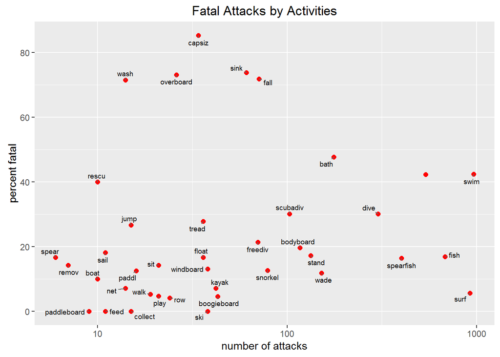

```r
#attack_by_activity %>% filter(freq>10) %>% select(freq) %>%
#  mutate(total_freqs=sum(freq)) %>% print(total_freqs)

#p <- subset(vFreqs,f>20,select = c(r,f,v)) %>% ggplot(aes(r, f, label = v))
p <- attack_by_activity %>% filter(freq>5) %>% ggplot(aes(freq,pct_fatal, label = activity_cat)) + ylab("percent fatal") + xlab("number of attacks") + ggtitle("Fatal Attacks by Activities")
p + geom_point(size=2,color="red") + scale_x_log10() + #xlim() #lims(x = c(15, 900), y = c(1, 100)) +
  geom_text_repel(cex=2.5)
```

Looking at the general attack **Type** and activities associated with them…

```r
activity_dat %>% filter(!is.na(activity_dat$Fatal)) %>%
  group_by(Type) %>%
  summarize(freq=n(),fatalities=sum(as.numeric(Fatal=="Y")),pct_fatal=round(fatalities/freq*100,2)) %>%
  arrange(desc(pct_fatal)) %>% kable(caption="Attack Type: number, fatalities")
```

Attack Type: number, fatalities

| Type | freq | fatalities | pct_fatal |
| --- | --- | --- | --- |
| sea disaster | 214 | 145 | 67.76 |
| invalid | 382 | 182 | 47.64 |
| unprovoked | 3982 | 1020 | 25.62 |
| boating | 258 | 9 | 3.49 |
| provoked | 509 | 15 | 2.95 |

```r
# invalid attack type ACTIVITY VARIATION -- LOOK AT THIS LATER
#activity_dat %>% filter(activity_dat$Type=="invalid") %>%
#  group_by(Activity) %>%
#  summarize(freq=n(),fatalities=sum(as.numeric(Fatal=="Y")),pct_fatal=round(fatalities/freq*100,2)) %>%
#  arrange(desc(pct_fatal)) %>% View() #kable(caption="Attack Type: number, fatalities")

#activity_dat %>% filter(!is.na(Fatal),Type=="invalid") %>%
#  group_by(Type,Activity) %>%
#  summarize(freq=n(),fatalities=sum(as.numeric(Fatal=="Y"))) %>%
#  arrange(desc(freq)) %>% head(30) #kable()

#ggplot(aes(freq,fatalities,colors=Type)) %>% geom_area() #head(20)
activities_by_type <-  tally(group_by(verbs_dat,verbs,Type,Fatal), sort=TRUE)
```

Comparing activities and types of attack…

```r
#activity_dat2 <- activity_dat %>% filter(!is.na(activity_dat$Fatal))

#activity_dat2 %>% spread(Activity,Type) %>% View()

## Sam, fix this please.
activity_dat %>% filter(!is.na(activity_dat$Fatal)) %>% spread(Activity,Type) %>%
  group_by(Fatal) %>%
  summarize(freq=n(),fatalities=sum(as.numeric(Fatal=="Y"))) %>%
  arrange(desc(freq)) %>% head(20)
```

```
## Source: local data frame [4 x 3]
##
##     Fatal  freq fatalities
##     (chr) (int)      (dbl)
## 1       N  3925          0
## 2       Y  1371       1371
## 3 UNKNOWN    48          0
## 4       F     1          0
```

Look at the activity word cloud…

```r
activity_tokens <- unlist(str_split(activity_dat$Activity," "))
num_tok <- length(activity_tokens)
num_uniq <- length(unique(activity_tokens))
act_word_counts <- as.data.frame(table(term=activity_tokens))

# This stop word list sucks
act_stop_words <- c("another", "been", "a", "as", "an", "by", "of", "or", "on", "that", "his", "but", "it", "its", "their", "than", "from", "have", "out", "were", "be", "is", "was", "later", "on", "with", "and", "the","&","/","-","for","in","to","into","him","her","he","she","that","being")

#library(SnowballC) stemmer


act_word_counts %>% filter(!term%in%act_stop_words) %>% arrange(desc(Freq)) %>% head(20)
```

```
##            term Freq
## 1      swimming 1047
## 2       surfing  934
## 3       fishing  699
## 4  spearfishing  409
## 5        diving  316
## 6         water  201
## 7         shark  184
## 8       bathing  179
## 9        wading  167
## 10     standing  145
## 11         boat  139
## 12 bodyboarding  125
## 13  scubadiving  117
## 14   freediving  109
## 15         fell   88
## 16    overboard   87
## 17   snorkeling   85
## 18     capsized   70
## 19          sea   68
## 20        after   63
```

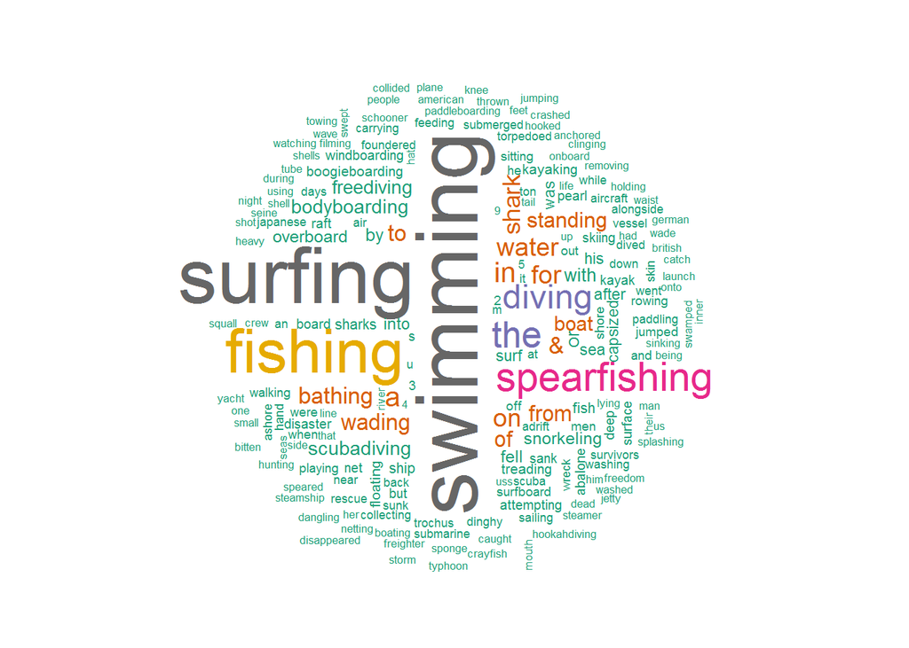

```r
wordcloud(act_word_counts$term,act_word_counts$Freq,
          min.freq = 8,
          random.order=FALSE,
          colors=brewer.pal(8, "Dark2"))
```